# Introdução ao framework {mlr3}

Alberson Miranda

2020-12-27

Esse é o primeiro post de uma série que irá tratar sobre o ecossistema {mlr3} (Lang et al. 2019). Ele é mais completo mas também muito mais complexo do que seu predecessor, o {mlr}, que teve sua versão inicial publicada no CRAN em 2013. O ecossistema permite um framework agnóstico (i.e. não depende dos algoritmos escolhidos), extensível e orientado a objeto, e, atualmente, permite vários tipos de tarefas, como classificação, regressão, análise de sobrevivência, forecasting, clustering, dentre outros. O {mlr3} tem diversas vantagens que o faz, IMHO, o *framework* mais completo para se trabalhar *machine learning* em R (R Core Team 2020) e elas ficarão claras ao longo dessas postagens.

# INTRODUÇÃO

O workflow padrão de um projeto de machine learning consiste em:

1. dividir sua amostra em treino e teste (*split*);
2. escolher o algoritmo[^1] apropriado para o tipo de tarefa;
3. passar a amostra de treino ao algoritmo para criar um modelo do relacionamento entre a variável de resposta (*output features*) e as explicativas (*input features*);
4. passar os dados de testes ao modelo treinado para produzir predições;
5. comparar as predições com os dados da amostra;
6. mensurar a performance do modelo através de medidas de acurácia estabelecidas.

[figure not shown]

O processo de repetir esse workflow várias vezes, separando a amostra treino em várias partes diferentes e usando outras como *fake test samples* é chamado de *resampling* e é um processo vital para a etapa de calibragem do modelo e para evitar o *overfitting*.

Dependendo dos dados, do tipo de tarefa e algoritmo escolhido, podem ser necessários vários filtros, como normalização, *feature selection* e tratamento de *outliers* ou dados faltantes. Para esses casos, o {mlr3} tem novas soluções que se destacam com muita vantagem em relação não só ao seu predecessor {mlr} como também a outros *frameworks* de *machine learning* em R, como o {caret} e o {tidymodels}.

## CARACTERÍSTICAS DE DESIGN

Alguns princípios gerais que norteiam o desenvolvimento do pacote e afetam muito seu uso são:

- Foco no *backend*. A maioria dos pacotes do ecossistema tem objetivo de processar e transformar dados, aplicar algoritmos e computar resultados. Visualizações são providenciadas em pacotes externos;
- Adoção da classe R6 (Chang 2020) para design orientado a objeto, *modify-in-place* e semântica de referência (falaremos um pouco sobre esses conceitos adiante);
- Adoção do {data.table} (Dowle and Srinivasan 2020) para manipulações de *data frames*. A combinação {R6} + {data.table} torna a performance um dos pontos fortes do ecossistema.
- Baixa dependência. Entretanto, os algortimos não são implementados no ecossistema, como no scikit-learn em Python. Para executar o XGBoost (Chen et al. 2020), por exemplo, deve-se ter instalado o pacote que o implementa.

## FORA DO ESCOPO

Como se trata de uma introdução, as etapas de *tunning* e *resampling*, assim como funcionalidades como os *pipelines*, serão abordadas em postagens futuras. Neste post trataremos apenas os conceitos básicos do *workflow*.

# DIRETO AO PONTO

Para conhecer as funcionalidades básicas do pacote, usaremos um dos *datasets* inclusos no R, o `swiss`. Esse *dataset* consiste na medição padronizada da fertilidade e indicadores socioeconômicos de 47 províncias da Suíça em 1888.

```r
# criando dataframe
data = swiss

# overview
skimr::skim(data)
```

Data summary

| Name | data |
| --- | --- |
| Number of rows | 47 |
| Number of columns | 6 |
| _______________________ |  |
| Column type frequency: |  |
| numeric | 6 |
| ________________________ |  |
| Group variables | None |

**Variable type: numeric**

| skim_variable | n_missing | complete_rate | mean | sd | p0 | p25 | p50 | p75 | p100 | hist |
| --- | --- | --- | --- | --- | --- | --- | --- | --- | --- | --- |
| Fertility | 0 | 1 | 70.14 | 12.49 | 35.00 | 64.70 | 70.40 | 78.45 | 92.5 | ▂▂▇▇▅ |
| Agriculture | 0 | 1 | 50.66 | 22.71 | 1.20 | 35.90 | 54.10 | 67.65 | 89.7 | ▃▃▆▇▅ |
| Examination | 0 | 1 | 16.49 | 7.98 | 3.00 | 12.00 | 16.00 | 22.00 | 37.0 | ▅▇▆▂▂ |
| Education | 0 | 1 | 10.98 | 9.62 | 1.00 | 6.00 | 8.00 | 12.00 | 53.0 | ▇▃▁▁▁ |
| Catholic | 0 | 1 | 41.14 | 41.70 | 2.15 | 5.20 | 15.14 | 93.12 | 100.0 | ▇▁▁▁▅ |
| Infant.Mortality | 0 | 1 | 19.94 | 2.91 | 10.80 | 18.15 | 20.00 | 21.70 | 26.6 | ▁▂▇▆▂ |

Dentre as varáveis disponíveis, podemos escolher modelar a mortalidade infantil `Infant.Mortality` baseada nas demais features, que são:

- `Fertility`: Medida de fertilidade. Assim como a mortalidade infantil, está escalonada entre 0-100.
- `Agriculture`: Percentual de homens envolvidos em agricultura como ocupação.
- `Examination`: Percentual de alistados bem avaliados nos exames do exército.
- `Education`: Percentual dos alistados com educação superior ao primário.
- `Catholic`: Percentual de católicos (em oposto a protestantes).

O *workflow* começa pela criação da `task`, que é um objeto que contém os dados e informações sobre a tarefa a ser executada, como a variável de resposta[^2] e as demais *features*, além de seus tipos. Como queremos realizar predições para uma variável numérica contínua, é uma tarefa de regressão.

```r
# importando pacote
library(mlr3verse)

# criando task
task_swiss = TaskRegr$new(
  id = "swiss",
  backend = data,
  target = "Infant.Mortality"
)
```

Notou algo estranho? Como o {mlr3} trabalha com a classe R6, seu manuseio é mais parecido com outras linguagens orientadas a objeto, como o Python. Essa classe tem duas propriedades especiais:

- Métodos pertencem a objetos e são chamados na forma `objeto$metodo()` e não como funções genéricas como `foo()`. Esse é o paradigma OOP (programação orientada à objetos). No caso acima, não há uma função para criar uma *task* como `task_regr_new()`, mas um método `new()` associado ao objeto `TaskRegr`;
- Os objetos da classe R6 são mutáveis, ou seja, eles são modificados no local (*modify-in-place*) e, portanto, têm semântica de referência. Isso significa que eles não são copiados a cada modificação, como os *data frames* comuns (classe S3), o que é um fator de alocação de memória e, consequentemente, lentidão.

O efeito colateral é que isso não é muito familiar para pessoas que não conhecem outras linguagens de programação além do R e no início pode parecer pouco natural e confuso.

Criado o objeto, podemos acessá-lo para verificar e visualizar as informações ali contidas:

```r
# verificando
task_swiss
```

```
## <TaskRegr:swiss> (47 x 6)
## * Target: Infant.Mortality
## * Properties: -
## * Features (5):
##   - dbl (3): Agriculture, Catholic, Fertility
##   - int (2): Education, Examination
```

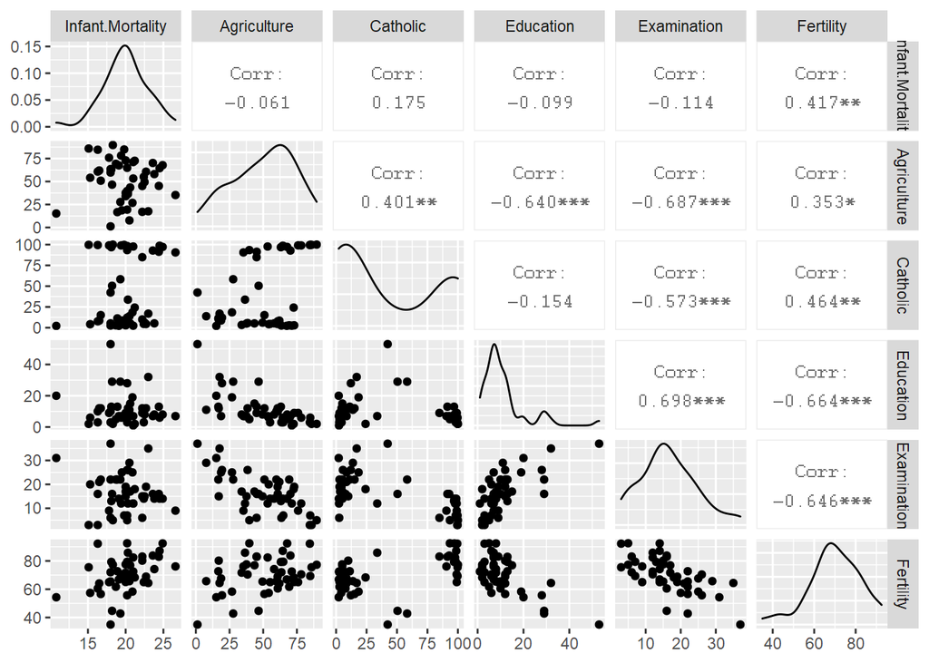

```r
# visualizando
autoplot(task_swiss, type = "pairs")
```

Podemos ver que apenas a fertilidade é linearmente correlacionada com a mortalidade infantil — quanto maior a fertilidade, maior a mortalidade —, e podemos esperar que tenha maior peso nas predições. As demais variáveis não apresentam correlação linear significativa com a variável de resposta. Entretanto, apresentam correlação moderada ou forte entre si, mas não a ponto de apresentar colinearidade, o que demandaria tratamento.

Agora selecionamos o algoritmo[^3] que será usado para treinar o modelo. Escolhi aqui o *XGBoost*. A lista completa pode ser acessada [por essa lista estática](https://mlr3extralearners.mlr-org.com/articles/learners/learner_status.html), [por essa lista dinâmica](https://mlr3extralearners.mlr-org.com/articles/learners/list_learners.html) ou pela função `mlr3extralearners::list_mlr3learners()`. Como mencionado anteriormente, os algoritmos não são implementados pelo ecossistema do {mlr3} e nas listas citadas constam os pacotes onde os algoritmos foram implementados e que devem ser baixados para o seu uso.

```r
# definindo o learner
l_xgboost = lrn("regr.xgboost")

# checando
l_xgboost
```

```
## <LearnerRegrXgboost:regr.xgboost>
## * Model: -
## * Parameters: nrounds=1, verbose=0
## * Packages: xgboost
## * Predict Type: response
## * Feature types: logical, integer, numeric
## * Properties: importance, missings, weights
```

Vamos entender o que o objeto `l_xgboost` nos diz.

1. **Model**: Vazio, pois ainda não há um modelo treinado;
2. **Parameters**: Os hiperparâmetros a serem escolhidos e tunados para performance do modelo;
3. **Packages**: O pacote onde o algorítmo foi implementado e de onde será importado pelo {mlr3};
4. **Predict Type**: Se “response” a predição é retornada como 0 ou 1, no caso de classificação, ou num valor para variável de resposta, no caso de regressão — neste caso, será a mortalidade infantil escalonada no intervalo [1, 100]. Se “prob,” para classificação, a predição retorna a probabilidade entre 0 e 1;
5. **Feature Type**: Os tipos de variáveis que o algoritmo é capaz de manipular. No caso do *XGBoost*, por exemplo, apenas variáveis numéricas podem ser utilizadas. Isso quer dizer que os fatores devem ser convertidos em valores binários (i.e. 0 ou 1), ou seja, deve-se tornar a matriz esparsa — no caso de um fator `sexo`, por exemplo, na fase de pre-processamento seriam criadas as colunas `sexo.masculino`, com valores de 1 ou 0, e `sexo.feminino`, também com 1 ou 0;
6. **Properties**: Propriedades e capacidades adicionais do algoritmo. Neste caso, o **XGBoost** possui a capacidade de computar e retornar os valores da importâncias das *features* para o modelo; a capacidade de trabalhar com dados faltantes (*missings*); a capacidade de computar e retornar os pesos associados às *features*.

```r
# acessando hiperparâmetros
head(as.data.table(l_xgboost$param_set))
```

```
##                  id    class lower upper               levels nlevels is_bounded special_vals default storage_type  tags
## 1:          booster ParamFct    NA    NA gbtree,gblinear,dart       3       TRUE    <list[0]>  gbtree    character train
## 2:        watchlist ParamUty    NA    NA                          Inf      FALSE    <list[0]>                 list train
## 3:              eta ParamDbl     0     1                          Inf       TRUE    <list[0]>     0.3      numeric train
## 4:            gamma ParamDbl     0   Inf                          Inf      FALSE    <list[0]>       0      numeric train
## 5:        max_depth ParamInt     0   Inf                          Inf      FALSE    <list[0]>       6      integer train
## 6: min_child_weight ParamDbl     0   Inf                          Inf      FALSE    <list[0]>       1      numeric train
```

Como o *tunning* de hiperparâmetros não é o assunto, vamos apenas configurar algumas coisas básicas para demonstrar como essas informações são acessadas e modificadas. O método para isso é o `param_set$values`:

```r
# hiperparâmetros
l_xgboost$param_set$values = list(
  # mandando o algoritmo parar depois de 10 iterações sem melhora no score
  early_stopping_rounds = 10,
  # mandando o algoritmo treinar mais lentamente
  eta = 0.1,
  # limitando profundidade da árvore
  max_depth = 5,
  # quantidade máxima de iterações
  nrounds = 100
)

# verificando
l_xgboost
```

```
## <LearnerRegrXgboost:regr.xgboost>
## * Model: -
## * Parameters: early_stopping_rounds=10, eta=0.1, max_depth=5, nrounds=100
## * Packages: xgboost
## * Predict Type: response
## * Feature types: logical, integer, numeric
## * Properties: importance, missings, weights
```

# TREINO E PREDIÇÃO

As próximas etapas são o treino e a predição — trataremos de *tunning* e *resampling* nos próximos posts. Primeiramente, o *split* do dataset em treino e teste. Para isso, usaremos a função `sample()` em dois métodos do objeto `task_swiss`, o `row_ids` e `nrow`. O primeiro enumera os índices de cada linha:

```r
# método row_ids
task_swiss$row_ids
```

```
##  [1]  1  2  3  4  5  6  7  8  9 10 11 12 13 14 15 16 17 18 19 20 21 22 23 24 25 26 27 28 29 30 31 32 33 34 35 36 37 38 39 40 41 42 43 44 45 46 47
```

Enquanto o segundo retorna a quantidade de linhas do dataset:

```r
# método row_ids
task_swiss$nrow
```

```
## [1] 47
```

Assim, podemos selecionar os índice do dataset em duas amostras aleatórias:

```r
# garantindo reprodutibilidade
set.seed(1)

# índices para amostra treino
train_set = sample(task_swiss$row_ids, 0.7 * task_swiss$nrow)

# índices para amostra teste
test_set = setdiff(task_swiss$row_ids, train_set)

# verificando
head(train_set)
```

```
## [1]  4 39  1 34 23 14
```

Com os índices selecionados, podemos realizar nosso treino apenas nos 70% escolhidos aleatoriamente da amostra, sem copiar os dados e alocar memória desnecessariamente:

```r
# treino
l_xgboost$train(task_swiss, row_ids = train_set)
```

```
## [03:23:46] WARNING: amalgamation/../src/objective/regression_obj.cu:174: reg:linear is now deprecated in favor of reg:squarederror.
## Will train until train_rmse hasn't improved in 10 rounds.
##
```

```r
# verificando
l_xgboost$model
```

```
## ##### xgb.Booster
## raw: 97.5 Kb
## call:
##   xgboost::xgb.train(data = data, nrounds = 100L, watchlist = list(
##     train = <pointer: 0x000002a90bd74120>), early_stopping_rounds = 10L,
##     eta = 0.1, max_depth = 5L, objective = "reg:linear")
## params (as set within xgb.train):
##   eta = "0.1", max_depth = "5", objective = "reg:linear", validate_parameters = "TRUE"
## xgb.attributes:
##   best_iteration, best_msg, best_ntreelimit, best_score, niter
## callbacks:
##   cb.print.evaluation(period = print_every_n)
##   cb.evaluation.log()
##   cb.early.stop(stopping_rounds = early_stopping_rounds, maximize = maximize,
##     verbose = verbose)
## # of features: 5
## niter: 100
## best_iteration : 100
## best_ntreelimit : 100
## best_score : 0.033438
## best_msg : [100] train-rmse:0.033438
## nfeatures : 5
## evaluation_log:
##     iter train_rmse
##        1  17.686886
##        2  16.014399
## ---
##       99   0.035096
##      100   0.033438
```

Como podemos ver, na primeira iteração o modelo obteve *rmse*[^4]. de 17.7, o que é alto considerando a escala [1-100] da mortalidade infantil. O modelo foi aumentando sua precisão no treino até 0.03, o que não significa que sua performance permaneça nesse nível quando extrapolado para a amostra teste ou novos dados, mas é um bom sinal. O esperado é que a performance real do modelo, após ser aplicado à amostra teste, fique entre a iteração inicial e final. Se ficar *melhor* do que a performance do teste, alguma coisa certamente está errada.

Vamos verificar qual a performance real após realizarmos as predições na amostra teste. Primeiro, passamos os índices de teste ao objeto do *learner* com o modelo e chamamos o método `predict()` para obter as predições.

```r
# predições
preds = l_xgboost$predict(task_swiss, row_ids = test_set)

# verificando
preds
```

```
## <PredictionRegr> for 15 observations:
##     row_id truth response
##          8  24.9 20.69299
##         11  24.5 20.65381
##         13  19.1 15.63718
## ---
##         40  20.5 19.55373
##         43  20.0 21.27585
##         47  19.3 21.82051
```

No objeto com as predições são armazenados tanto os valores preditos pelo modelo (`response`) quanto os valores da amostra (`truth`). Esses valores então podem ser comparados para calcular a acurácia do modelo através do método `score()`:

```r
# acurácia
preds$score(list(
  msr("regr.rmse"),
  msr("regr.mae")
))
```

```
## regr.rmse  regr.mae
##  2.587082  2.214176
```

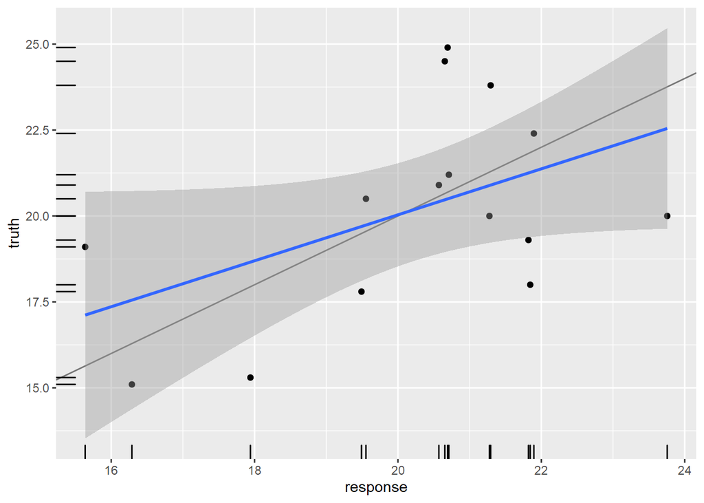

```r
# visualizando
autoplot(preds)
```

A *rmse* do modelo na amostra teste ficou em apenas 2.59 unidades, o que é uma performance muito boa!

# INTERPRETAÇÃO

Como o XGBoost possui a propriedade de *feature importance*, podemos extraí-la com o método `importance()`:

```r
# feature importance
l_xgboost$importance()
```

```
##    Catholic Agriculture   Fertility Examination   Education
##  0.39696784  0.24723198  0.20219343  0.10340228  0.05020448
```

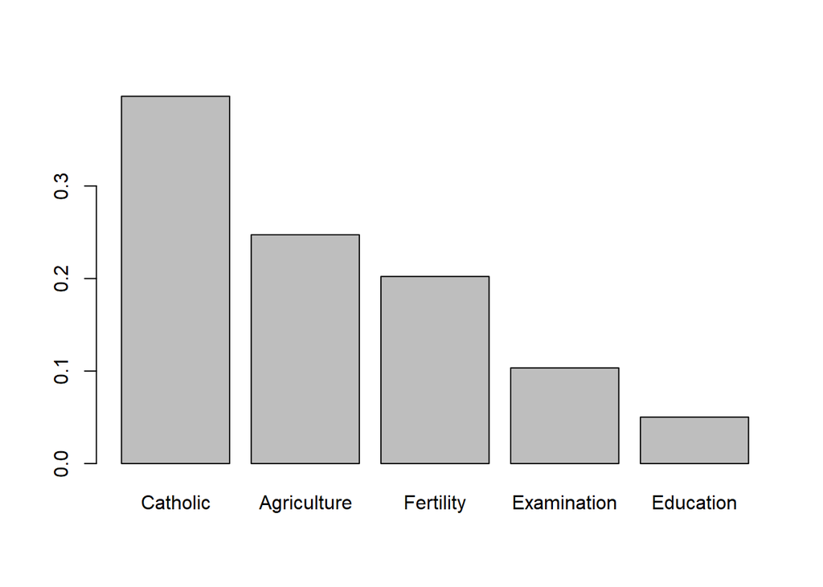

```r
# visualizando
barplot(l_xgboost$importance())
```

Entretanto, somente a importância não nos descreve o relacionamento da *feature* com a variável de resposta, nem mesmo sua direção, sendo uma medida muito pobre de interpretação. Discutiremos técnicas de interpretação em outras postagens.

# REFERÊNCIAS

Chang, Winston. 2020. *R6: Encapsulated Classes with Reference Semantics*. https://CRAN.R-project.org/package=R6.

Chen, Tianqi, Tong He, Michael Benesty, Vadim Khotilovich, Yuan Tang, Hyunsu Cho, Kailong Chen, et al. 2020. *Xgboost: Extreme Gradient Boosting*. https://CRAN.R-project.org/package=xgboost.

Dowle, Matt, and Arun Srinivasan. 2020. *Data.table: Extension of ‘Data.frame‘*. https://CRAN.R-project.org/package=data.table.

Lang, Michel, Martin Binder, Jakob Richter, Patrick Schratz, Florian Pfisterer, Stefan Coors, Quay Au, Giuseppe Casalicchio, Lars Kotthoff, and Bernd Bischl. 2019. “mlr3: A Modern Object-Oriented Machine Learning Framework in R.” *Journal of Open Source Software*, December. https://doi.org/10.21105/joss.01903.

R Core Team. 2020. *R: A Language and Environment for Statistical Computing*. Vienna, Austria: R Foundation for Statistical Computing. https://www.R-project.org/.

[^1]: No {mlr3} é chamado de *learner*.
[^2]: Também chamada de *output feature* ou *label*.
[^3]: Aqui trabalharemos apenas com um, mas em posts futuros utilizaremos de diversas formas — pipelines com diferentes *features*, *stacking* etc.
[^4]: Raiz do Erro Médio Quadrático